# UFRNprojetos

## Análise dos Dados de empréstimos dos acervos do sistema de bibliotecas da UFRN.

#### Importando as bibliotecas necessárias...

```python
import pandas as pd
import numpy as np
import seaborn as sns
import matplotlib.ticker as ticker
import matplotlib.pyplot as plt
```

```python
## Importando os Datasets e unindo.
try:
    df_2010_1 = pd.read_csv('emprestimos-20101.csv')
    df_2010_2 = pd.read_csv('emprestimos-20102.csv')
    df_2011_1 = pd.read_csv('emprestimos-20111.csv')
    df_2011_2 = pd.read_csv('emprestimos-20112.csv')
    df_2012_1 = pd.read_csv('emprestimos-20121.csv')
    df_2012_2 = pd.read_csv('emprestimos-20122.csv')
    df_2013_1 = pd.read_csv('emprestimos-20131.csv')
    df_2013_2 = pd.read_csv('emprestimos-20132.csv')
    df_2014_1 = pd.read_csv('emprestimos-20141.csv')
    df_2014_2 = pd.read_csv('emprestimos-20142.csv')
    df_2015_1 = pd.read_csv('emprestimos-20151.csv')
    df_2015_2 = pd.read_csv('emprestimos-20152.csv')
    df_2016_1 = pd.read_csv('emprestimos-20161.csv')
    df_2016_2 = pd.read_csv('emprestimos-20162.csv')
    df_2017_1 = pd.read_csv('emprestimos-20171.csv')
    df_2017_2 = pd.read_csv('emprestimos-20172.csv')
    df_2018_1 = pd.read_csv('emprestimos-20181.csv')
    df_2018_2 = pd.read_csv('emprestimos-20182.csv')
    df_2019_1 = pd.read_csv('emprestimos-20191.csv')
    df_2019_2 = pd.read_csv('emprestimos-20192.csv')
    df_2020_1 = pd.read_csv('emprestimos-20201.csv')
    book_data = pd.read_parquet('dados_exemplares.parquet')
    library_loan = [df_2010_1,df_2010_2,df_2011_1,df_2011_2,df_2012_1,df_2012_2,df_2013_1,df_2013_2,df_2014_1,df_2014_2,df_2015_1,df_2015_2,df_2016_1,df_2016_2,df_2017_1,df_2017_2,df_2018_1,df_2018_2,df_2019_1,df_2019_2,
df_2020_1]
except FileNotFoundError:
    print('Não achou os arquivos selecionados')
```

```python
library_loan = pd.concat(library_loan, ignore_index = True)
```

```python
# Checando se há duplicatas
display(library_loan.value_counts())
```

```
id_emprestimo  codigo_barras  data_renovacao                 data_emprestimo                data_devolucao                 matricula_ou_siape  tipo_vinculo_usuario
709704         2006021442     2010/01/17 18:56:43.923000000  2010/01/04 09:58:46.522000000  2010/02/01 13:59:02.528000000  2.008010e+09        ALUNO DE GRADUAÇÃO        7
709705         2009032168     2010/01/17 18:56:43.909000000  2010/01/04 09:58:46.549000000  2010/01/20 13:14:34.464000000  2.008010e+09        ALUNO DE GRADUAÇÃO        7
709698         2009047725     2010/01/18 14:44:41.163000000  2010/01/04 09:21:19.099000000  2010/02/02 12:02:38.444000000  2.009047e+09        ALUNO DE GRADUAÇÃO        3
709686         2006017618     2010/01/26 08:07:01.738000000  2010/01/04 08:08:44.081000000  2010/02/25 07:36:25.800000000  2.008112e+09        ALUNO DE PÓS-GRADUAÇÃO    2
2461099        2012008348     2016/06/27 20:35:46.855000000  2016/06/14 11:20:33.254000000  2016/07/11 14:37:29.000000000  2.015022e+09        ALUNO DE GRADUAÇÃO        2
                                                                                                                                                                        ..
1443389        2011018954     2013/03/22 13:18:55.037000000  2013/03/07 11:21:26.480000000  2013/04/08 20:26:07.000000000  2.010046e+09        ALUNO DE GRADUAÇÃO        1
1443390        2009056314     2013/03/21 09:28:45.689000000  2013/03/07 11:21:28.899000000  2013/04/05 18:18:00.000000000  2.011015e+09        ALUNO DE GRADUAÇÃO        1
1443393        2012037906     2013/03/20 20:17:10.574000000  2013/03/07 11:24:19.326000000  2013/03/25 08:58:44.000000000  2.011038e+09        ALUNO DE GRADUAÇÃO        1
1443395        2011033069     2013/04/07 01:06:51.679000000  2013/03/07 11:25:22.661000000  2013/05/07 16:19:34.000000000  2.011106e+09        ALUNO DE PÓS-GRADUAÇÃO    1
10322328       2014070441     2018/01/15 12:26:00.697000000  2017/12/29 18:21:09.060000000  2018/01/31 18:50:25.000000000  2.014063e+09        ALUNO DE GRADUAÇÃO        1
Name: count, Length: 968028, dtype: int64
```

```python
library_loan = library_loan.drop_duplicates()
```

```python
for i in np.array(library_loan.columns):
    if library_loan[i].isnull().sum() != 0:
        print(f"Na coluna {i} há: {library_loan[i].isnull().sum()} valores nulos")
```

```
Na coluna data_renovacao há: 1285709 valores nulos
Na coluna data_devolucao há: 6471 valores nulos
Na coluna matricula_ou_siape há: 3170 valores nulos
```

```python
total_loan = library_loan.merge(book_data)
total_loan.drop('registro_sistema',inplace=True, axis = 1)
total_loan['matricula_ou_siape'] = total_loan['matricula_ou_siape'].astype('str')
display(total_loan.head(2))
```

|  | id_emprestimo | codigo_barras | data_renovacao | data_emprestimo | data_devolucao | matricula_ou_siape | tipo_vinculo_usuario | id_exemplar | colecao | biblioteca | status_material | localizacao |
| --- | --- | --- | --- | --- | --- | --- | --- | --- | --- | --- | --- | --- |
| 0 | 709684 | L095049 | NaN | 2010/01/04 07:44:10.721000000 | 2010/01/05 16:26:12.662000000 | 2008023265.0 | ALUNO DE GRADUAÇÃO | 13259 | Acervo Circulante | Biblioteca Central Zila Mamede | REGULAR | 630 |
| 1 | 709685 | L167050 | NaN | 2010/01/04 07:44:10.750000000 | 2010/01/12 07:34:13.934000000 | 2008023265.0 | ALUNO DE GRADUAÇÃO | 70865 | Acervo Circulante | Biblioteca Central Zila Mamede | REGULAR | 647 |

```python
# Nomeando os livros por tema
Theme = []
for i in total_loan['localizacao']:
    if i < 100:
        Theme.append('Generalidades. Ciência e conhecimento')
    elif i < 200:
        Theme.append('Filosofia e psicologia')
    elif i < 300:
        Theme.append('Religião')
    elif i < 400:
        Theme.append('Ciências sociais')
    elif i < 500:
        Theme.append('Classe vaga. Provisoriamente não ocupada')
    elif i < 600:
        Theme.append('Matemática e ciências naturais')
    elif i < 700:
        Theme.append('Ciências aplicadas')
    elif i < 800:
        Theme.append('Belas artes')
    elif i < 900:
        Theme.append('Linguagem. Língua. Linguística')
    elif i < 1000:
        Theme.append('Geografia. Biografia. História')

total_loan['CDU_geral'] = Theme
```

```python
print(f'A quantidade total de empréstimos foi de {len(total_loan['id_emprestimo'].drop_duplicates())}\nA quantidade total de exemplares emprestados foi de {len(total_loan)}')
```

```
A quantidade total de empréstimos foi de 2068724
A quantidade total de exemplares emprestados foi de 2072522
```

```python
max_value = total_loan['id_exemplar'].value_counts().max()
max_index = total_loan['id_exemplar'].value_counts().idxmax()
print(f"Exemplar {max_index} é o mais emprestado com {max_value} requisições ")
```

```
Exemplar 937412 é o mais emprestado com 196 requisições
```

#### Análise da quantidade de livros emprestados

```python
datetime = pd.DataFrame(total_loan['data_emprestimo'].value_counts().reset_index())
datetime.columns = ['Data','Quantidade']
datetime['Data'] = pd.to_datetime(datetime['Data'])
display(datetime)
```

|  | Data | Quantidade |
| --- | --- | --- |
| 0 | 2015-06-10 18:51:56.994 | 3 |
| 1 | 2018-02-22 10:45:11.523 | 3 |
| 2 | 2014-01-28 14:49:50.505 | 3 |
| 3 | 2015-08-18 19:11:08.653 | 3 |
| 4 | 2014-07-14 15:35:51.822 | 3 |
| ... | ... | ... |
| 2068686 | 2013-06-06 17:41:22.688 | 1 |
| 2068687 | 2013-06-06 17:40:06.074 | 1 |
| 2068688 | 2013-06-06 17:39:44.209 | 1 |
| 2068689 | 2013-06-06 17:34:42.071 | 1 |
| 2068690 | 2020-06-09 11:54:02.852 | 1 |

2068691 rows × 2 columns

```python
loan_by_year = datetime.groupby(datetime['Data'].dt.year).sum(numeric_only=True)
display(loan_by_year)
```

| Data | Quantidade |
| --- | --- |
| 2010 | 161394 |
| 2011 | 196390 |
| 2012 | 221365 |
| 2013 | 234749 |
| 2014 | 219189 |
| 2015 | 213582 |
| 2016 | 215900 |
| 2017 | 218462 |
| 2018 | 194080 |
| 2019 | 171801 |
| 2020 | 25610 |

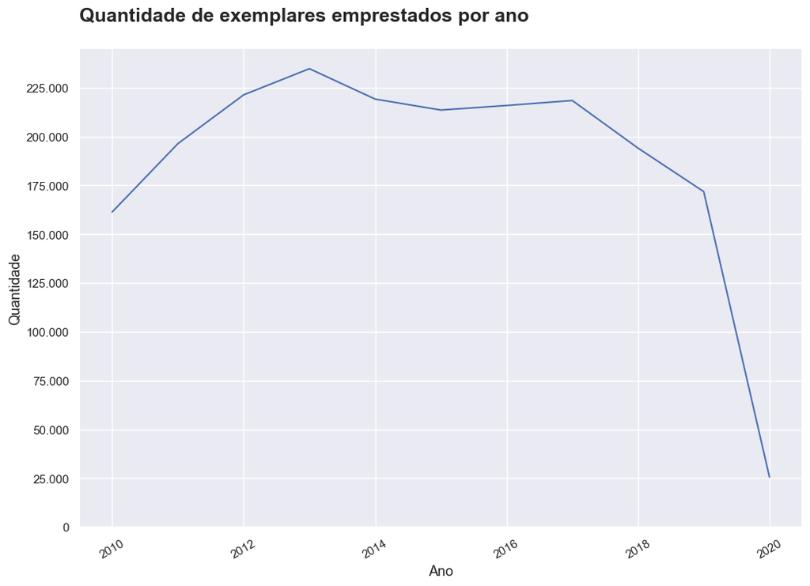

```python
sns.set_theme(style='darkgrid')
plt.figure(figsize=(12,8))
ax = sns.lineplot(x = 'Data' , y = 'Quantidade' , data = loan_by_year)
ax.set_title("Quantidade de exemplares emprestados por ano"+"\n",size=18,loc='left',weight='bold')
ax.set_xlabel('Ano', fontsize = 13)
ax.set_ylabel('Quantidade', fontsize = 13)
ax.tick_params(axis = 'x', rotation = 30 )
ax.set_yticks(list(np.arange(0,loan_by_year['Quantidade'].max() + 1,step = 25000)))
ax.yaxis.set_major_formatter(ticker.FuncFormatter(lambda x, p: format(int(x), ',').replace(',','.')))
plt.show()
```

### Análise dos Dados - Perguntas a se fazer

É perceptível que o número de empréstimos diminuíram de forma notável a partir do ano de 2013, isso pode ter ocorrido por diversos fatores como:

- Número de alunos em decadência
- Falta de Exemplares
- Acervo desatualizado
- Satisfação dos Usuários
- Ascensão dos Meios Digitais

Em 2017 houve um leve crescimento novamente o que pode ter acontecido? Mas, em 2019 houve uma grande queda, porquê?

### Quantos exemplares foram emprestados por mês?

```python
loan_by_month = datetime.groupby(datetime['Data'].dt.month).sum(numeric_only=True)
meses = {1:'Jan',2:'Fev',3:'Mar',4:'Abr',
        5:'Mai', 6:'Jun',7:'Jul',8:'Ago',
        9:'Set',10:'Out',11:'Nov',12:'Dez'}
loan_by_month.index = loan_by_month.index.map(meses)
display(loan_by_month)
```

| Data | Quantidade |
| --- | --- |
| Jan | 67514 |
| Fev | 210200 |
| Mar | 252185 |
| Abr | 208725 |
| Mai | 202530 |
| Jun | 138123 |
| Jul | 123790 |
| Ago | 232793 |
| Set | 208234 |
| Out | 188410 |
| Nov | 164222 |
| Dez | 75796 |

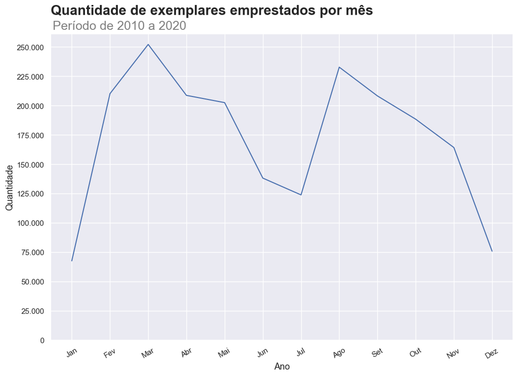

```python
sns.set_theme(style='darkgrid')
plt.figure(figsize=(12,8))
ax = sns.lineplot(x = 'Data' , y = 'Quantidade' , data = loan_by_month)
ax.set_title("Quantidade de exemplares emprestados por mês"+"\n",size=20,loc='left',weight='bold')
ax.text(s='Período de 2010 a 2020',x=-0.5,y=265000,fontsize=18, ha='left',color='gray')
ax.set_xlabel('Ano', fontsize = 13)
ax.set_ylabel('Quantidade', fontsize = 13)
ax.tick_params(axis = 'x', rotation = 30 )
ax.set_yticks(list(np.arange(0,loan_by_month['Quantidade'].max() + 1,step = 25000)))
ax.yaxis.set_major_formatter(ticker.FuncFormatter(lambda x, p: format(int(x), ',').replace(',','.')))
plt.show()
```

### Análise dos Dados - Perguntas a se fazer

- Pode-se visualizar que os meses com maiores números de exemplares emprestados foram em março e agosto.
- Meses como Janeiro, Julho e Dezembro têm os menores números, provavelmente por serem meses de férias.
- Nota-se também a grande queda no mês de junho. Cabe aqui um alerta para se investigar mais, o que está ocorrendo e desenvolver estratégias para aumentar o número de empréstimos.

### Qual é a quantidade de empréstimos por hora ao longo do dia ?

```python
loan_by_hour = datetime.groupby(datetime['Data'].dt.hour).sum(numeric_only=True)
loan_by_hour.index.name = 'Hora'
loan_by_hour = loan_by_hour.reset_index()
display(loan_by_hour)
```

|  | Hora | Quantidade |
| --- | --- | --- |
| 0 | 0 | 17 |
| 1 | 6 | 14 |
| 2 | 7 | 18777 |
| 3 | 8 | 103416 |
| 4 | 9 | 131273 |
| 5 | 10 | 185839 |
| 6 | 11 | 180048 |
| 7 | 12 | 148754 |
| 8 | 13 | 126987 |
| 9 | 14 | 150876 |
| 10 | 15 | 166672 |
| 11 | 16 | 210655 |
| 12 | 17 | 185340 |
| 13 | 18 | 182520 |
| 14 | 19 | 102129 |
| 15 | 20 | 127716 |
| 16 | 21 | 51191 |
| 17 | 22 | 247 |
| 18 | 23 | 51 |

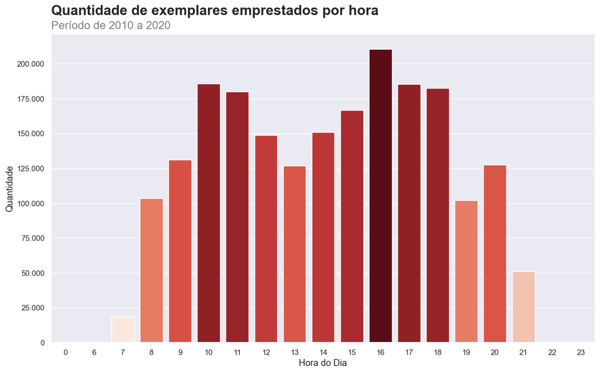

```python
sns.set_theme(style='darkgrid')
plt.figure(figsize=(14,8))
ax = sns.barplot(x = 'Hora' , y = 'Quantidade' , data = loan_by_hour, palette= 'Reds', hue = "Quantidade")
ax.set_title("Quantidade de exemplares emprestados por hora"+"\n",size=20,loc='left',weight='bold')
ax.text(s='Período de 2010 a 2020',x=-0.5,y=225000,fontsize=16, ha='left',color='gray')
ax.set_xlabel('Hora do Dia', fontsize = 13)
ax.set_ylabel('Quantidade', fontsize = 13)
ax.set_yticks(list(np.arange(0,loan_by_hour['Quantidade'].max() + 1,step = 25000)))
ax.yaxis.set_major_formatter(ticker.FuncFormatter(lambda x, p: format(int(x), ',').replace(',','.')))
ax.legend([],[],frameon = False)
plt.show()
```

É possível perceber que os horários com maior atendimento são entre 10h-18h, com o maior pico às 16hrs.. Os períodos do começo da manhã (entre 7h e 9) e da noite (entre 19h e 22) podem ser os melhores horários para que se realizem as demais atividades além do atendimento.

## Análise de Dados Categóricos

```python
total_loan.head()
```

|  | id_emprestimo | codigo_barras | data_renovacao | data_emprestimo | data_devolucao | matricula_ou_siape | tipo_vinculo_usuario | id_exemplar | colecao | biblioteca | status_material | localizacao | CDU_geral |
| --- | --- | --- | --- | --- | --- | --- | --- | --- | --- | --- | --- | --- | --- |
| 0 | 709684 | L095049 | NaN | 2010/01/04 07:44:10.721000000 | 2010/01/05 16:26:12.662000000 | 2008023265.0 | ALUNO DE GRADUAÇÃO | 13259 | Acervo Circulante | Biblioteca Central Zila Mamede | REGULAR | 630 | Ciências aplicadas |
| 1 | 709685 | L167050 | NaN | 2010/01/04 07:44:10.750000000 | 2010/01/12 07:34:13.934000000 | 2008023265.0 | ALUNO DE GRADUAÇÃO | 70865 | Acervo Circulante | Biblioteca Central Zila Mamede | REGULAR | 647 | Ciências aplicadas |
| 2 | 709686 | 2006017618 | 2010/01/26 08:07:01.738000000 | 2010/01/04 08:08:44.081000000 | 2010/02/25 07:36:25.800000000 | 2008112114.0 | ALUNO DE PÓS-GRADUAÇÃO | 195347 | Acervo Circulante | Biblioteca Setorial Prof. Rodolfo Helinski - E... | REGULAR | 640 | Ciências aplicadas |
| 3 | 709687 | L184117 | 2010/01/18 11:07:46.470000000 | 2010/01/04 08:24:21.284000000 | 2010/02/03 08:58:45.692000000 | 200721119.0 | ALUNO DE GRADUAÇÃO | 131639 | Acervo Circulante | Biblioteca Central Zila Mamede | REGULAR | 609 | Ciências aplicadas |
| 4 | 709688 | 2007027500 | 2010/01/19 15:59:26.464000000 | 2010/01/04 08:27:33.569000000 | 2010/02/03 13:06:30.662000000 | 2009045971.0 | ALUNO DE GRADUAÇÃO | 225646 | Acervo Circulante | Biblioteca Central Zila Mamede | REGULAR | 686 | Ciências aplicadas |

```python
display(total_loan['tipo_vinculo_usuario'].unique())
display(total_loan['colecao'].unique())
display(total_loan['biblioteca'].unique())
display(total_loan['CDU_geral'].unique())
```

```
array(['ALUNO DE GRADUAÇÃO', 'ALUNO DE PÓS-GRADUAÇÃO', 'DOCENTE',
       'SERVIDOR TÉCNICO-ADMINISTRATIVO', 'DOCENTE EXTERNO',
       'ALUNO MÉDIO/TÉCNICO', 'USUÁRIO EXTERNO', 'OUTROS'], dtype=object)
```

```
array(['Acervo Circulante', 'Folhetos', 'Teses', 'Dissertações',
       'Monografias', 'Publicações de Autores do RN',
       'Publicações da UFRN', 'Multimeios', 'Coleção Mossoroense',
       'Eventos', 'Trabalho Acadêmico', 'Obras de Referência',
       'Obras Raras', 'Literatura de Cordel', 'Coleção Zila Mamede',
       'Necessidades Educacionais Específicas'], dtype=object)
```

```
array(['Biblioteca Central Zila Mamede',
       'Biblioteca Setorial Prof. Rodolfo Helinski - Escola Agrícola de Jundiaí - EAJ  - Macaiba',
       'Biblioteca Setorial Bertha Cruz Enders - \xadEscola de Saúde da UFRN - ESUFRN',
       'Biblioteca Setorial do Centro Ciências da Saúde - CCS',
       'Biblioteca Setorial Prof. Alberto Moreira Campos - \xadDepartamento de Odontologia',
       'Biblioteca Setorial Prof. Ronaldo Xavier de Arruda - CCET',
       'Biblioteca Setorial do Centro de Ciências Humanas, Letras e Artes - CCHLA',
       'Biblioteca Setorial Prof. Horácio Nicolas Solimo - \xad Engenharia Química - EQ - CT',
       'Biblioteca Setorial Prof. Francisco Gurgel De Azevedo - Instituto Química - IQ',
       'Biblioteca Setorial do Centro Ciências Sociais Aplicadas - CCSA',
       'Biblioteca Setorial do Departamento de Artes - DEART',
       'Biblioteca Setorial Prof. Dr. Marcelo Bezerra de Melo Tinôco - DARQ - \xadCT',
       'Biblioteca Setorial Árvore do Conhecimento - Instituto do Cérebro - ICe',
       'Biblioteca Setorial Moacyr de Góes - CE',
       'Biblioteca Setorial Prof. Leopoldo Nelson - \xadCentro de Biociências - CB',
       'Biblioteca Setorial Dr. Paulo Bezerra - EMCM/RN - Caicó',
       'Biblioteca Setorial Pe. Jaime Diniz - Escola de Música - EMUFRN',
       'Biblioteca Setorial Profª. Maria Lúcia da Costa Bezerra - \xadCERES\xad - Caicó',
       'Biblioteca Setorial Profª. Maria José Mamede Galvão - FELCS - Currais Novos',
       'Biblioteca Setorial do Núcleo de Educação da Infância - NEI',
       'Biblioteca Setorial da Faculdade de Ciências da Saúde do Trairi - FACISA - Santa Cruz',
       'Biblioteca Setorial do Núcleo de Ensino Superior do Agreste - NESA - Nova Cruz'],
      dtype=object)
```

```
array(['Ciências aplicadas', 'Linguagem. Língua. Linguística',
       'Ciências sociais', 'Geografia. Biografia. História',
       'Matemática e ciências naturais', 'Religião',
       'Generalidades. Ciência e conhecimento', 'Filosofia e psicologia',
       'Belas artes'], dtype=object)
```

```python
def tabela_frequencia(variable):
    table = pd.DataFrame(total_loan[variable].value_counts())
    table.columns = ["Quantidade"]
    table['percentual'] = round((table['Quantidade'] / table['Quantidade'].sum())*100,2)
    return table
```

```python
tabela_frequencia('tipo_vinculo_usuario')
```

| tipo_vinculo_usuario | Quantidade | percentual |
| --- | --- | --- |
| ALUNO DE GRADUAÇÃO | 1612324 | 77.80 |
| ALUNO DE PÓS-GRADUAÇÃO | 302541 | 14.60 |
| DOCENTE | 70981 | 3.42 |
| SERVIDOR TÉCNICO-ADMINISTRATIVO | 32184 | 1.55 |
| ALUNO MÉDIO/TÉCNICO | 28029 | 1.35 |
| DOCENTE EXTERNO | 23949 | 1.16 |
| USUÁRIO EXTERNO | 2509 | 0.12 |
| OUTROS | 5 | 0.00 |

É perceptível, que o maior público da biblioteca é, de fato, os graduandos, provavelmente devido a quantidade de alunos que é superior a de outros vínculos. Em seguida, temos os alunos de pós-graduação com aproximadamente 15%

```python
tabela_frequencia('colecao')
```

| colecao | Quantidade | percentual |
| --- | --- | --- |
| Acervo Circulante | 2053120 | 99.06 |
| Multimeios | 7954 | 0.38 |
| Monografias | 4021 | 0.19 |
| Dissertações | 2406 | 0.12 |
| Obras de Referência | 1954 | 0.09 |
| Publicações de Autores do RN | 866 | 0.04 |
| Publicações da UFRN | 764 | 0.04 |
| Teses | 714 | 0.03 |
| Folhetos | 271 | 0.01 |
| Necessidades Educacionais Específicas | 130 | 0.01 |
| Trabalho Acadêmico | 115 | 0.01 |
| Eventos | 101 | 0.00 |
| Coleção Mossoroense | 44 | 0.00 |
| Coleção Zila Mamede | 30 | 0.00 |
| Literatura de Cordel | 24 | 0.00 |
| Obras Raras | 8 | 0.00 |

Evidentemente, a coleção mais emprestada é o do Acervo Circulante com 99%. Enquanto, as Monografias, Teses, Dissertações e Trabalhos Acadêmicos, poderiam estar sendo mais consultadas para que haja um crescimento das discussões de pesquisa interna da instituição.

Já, as coleções: Coleção Mossoroense, Coleção Zila Mamede, Literatura de Cordel, Obras Raras devem ter uma atenção especial em entender a razão que estão com números tão pequenos de frequência.

```python
tabela_frequencia('biblioteca')
```

| biblioteca | Quantidade | percentual |
| --- | --- | --- |
| Biblioteca Central Zila Mamede | 1426122 | 68.81 |
| Biblioteca Setorial do Centro Ciências da Saúde - CCS | 118614 | 5.72 |
| Biblioteca Setorial da Faculdade de Ciências da Saúde do Trairi - FACISA - Santa Cruz | 77609 | 3.74 |
| Biblioteca Setorial Prof. Alberto Moreira Campos - Departamento de Odontologia | 66447 | 3.21 |
| Biblioteca Setorial Profª. Maria Lúcia da Costa Bezerra - CERES - Caicó | 61478 | 2.97 |
| Biblioteca Setorial Bertha Cruz Enders - Escola de Saúde da UFRN - ESUFRN | 46040 | 2.22 |
| Biblioteca Setorial do Centro de Ciências Humanas, Letras e Artes - CCHLA | 40744 | 1.97 |
| Biblioteca Setorial Dr. Paulo Bezerra - EMCM/RN - Caicó | 32097 | 1.55 |
| Biblioteca Setorial Profª. Maria José Mamede Galvão - FELCS - Currais Novos | 29089 | 1.40 |
| Biblioteca Setorial Prof. Rodolfo Helinski - Escola Agrícola de Jundiaí - EAJ - Macaiba | 27219 | 1.31 |
| Biblioteca Setorial Prof. Francisco Gurgel De Azevedo - Instituto Química - IQ | 26923 | 1.30 |
| Biblioteca Setorial do Núcleo de Educação da Infância - NEI | 23656 | 1.14 |
| Biblioteca Setorial Prof. Ronaldo Xavier de Arruda - CCET | 22749 | 1.10 |
| Biblioteca Setorial Pe. Jaime Diniz - Escola de Música - EMUFRN | 21476 | 1.04 |
| Biblioteca Setorial do Departamento de Artes - DEART | 17099 | 0.83 |
| Biblioteca Setorial Prof. Leopoldo Nelson - Centro de Biociências - CB | 12900 | 0.62 |
| Biblioteca Setorial do Centro Ciências Sociais Aplicadas - CCSA | 10533 | 0.51 |
| Biblioteca Setorial Prof. Dr. Marcelo Bezerra de Melo Tinôco - DARQ - CT | 5057 | 0.24 |
| Biblioteca Setorial Prof. Horácio Nicolas Solimo -  Engenharia Química - EQ - CT | 4098 | 0.20 |
| Biblioteca Setorial Moacyr de Góes - CE | 1036 | 0.05 |
| Biblioteca Setorial Árvore do Conhecimento - Instituto do Cérebro - ICe | 919 | 0.04 |
| Biblioteca Setorial do Núcleo de Ensino Superior do Agreste - NESA - Nova Cruz | 617 | 0.03 |

Era de se esperar, que a Biblioteca Central Zila Mamede houvesse uma maior predominência, por conta de seu tamanho.

Mas, é necessário entender o contexto de cada biblitoeca em si:

- Quantidade de Alunos
- A quantidade esperada de empréstimos.
- Ações e Investimentos

### Quantos foram pela CDU geral?

```python
tabela_frequencia('CDU_geral')
```

| CDU_geral | Quantidade | percentual |
| --- | --- | --- |
| Ciências aplicadas | 1425473 | 68.78 |
| Ciências sociais | 369536 | 17.83 |
| Matemática e ciências naturais | 68744 | 3.32 |
| Generalidades. Ciência e conhecimento | 62521 | 3.02 |
| Religião | 62295 | 3.01 |
| Filosofia e psicologia | 60563 | 2.92 |
| Geografia. Biografia. História | 7989 | 0.39 |
| Belas artes | 7911 | 0.38 |
| Linguagem. Língua. Linguística | 7490 | 0.36 |

Há uma grande diferença em relação as Ciências Aplicadas e Ciências Sociais em relação ao restante. Se analisarmos temas como Geografia/Biografia/História, Belas Artes e Linguagem, predomina os números baixos.

Possíveis Motivos:

- O Acervo está atualizado?
- O público busca ou necessita tais informações? Se sim, elas são mais facilmente encontradas em outros locais?
- Melhorar as ações de Marketing acerca desse tema.

```python
grad_loan = total_loan.query('tipo_vinculo_usuario == "ALUNO DE GRADUAÇÃO"')
print(grad_loan['colecao'].value_counts())
```

```
colecao
Acervo Circulante                        1600155
Multimeios                                  4652
Monografias                                 3572
Dissertações                                1152
Obras de Referência                         1047
Publicações de Autores do RN                 595
Publicações da UFRN                          466
Teses                                        245
Folhetos                                     180
Trabalho Acadêmico                            81
Necessidades Educacionais Específicas         73
Eventos                                       57
Coleção Mossoroense                           17
Coleção Zila Mamede                           15
Literatura de Cordel                          11
Obras Raras                                    6
Name: count, dtype: int64
```

```python
grad_loan_col = grad_loan.query('colecao == "Acervo Circulante"')
grad_loan_col = pd.DataFrame(grad_loan_col)
grad_loan_col['data_emprestimo'] = pd.to_datetime(grad_loan_col['data_emprestimo'])
grad_loan_col['Ano'] = grad_loan_col['data_emprestimo'].dt.year
grad_loan_col['Mes'] = grad_loan_col['data_emprestimo'].dt.month
grad_loan_date = grad_loan_col.loc[:,['Ano','Mes']]
grad_loan_date = grad_loan_date.value_counts().to_frame('Quantidade').reset_index()
display(grad_loan_date)
```

|  | Ano | Mes | Quantidade |
| --- | --- | --- | --- |
| 0 | 2012 | 3 | 22797 |
| 1 | 2015 | 3 | 22483 |
| 2 | 2013 | 4 | 21853 |
| 3 | 2017 | 3 | 21735 |
| 4 | 2016 | 3 | 21692 |
| ... | ... | ... | ... |
| 118 | 2016 | 1 | 2670 |
| 119 | 2019 | 1 | 2276 |
| 120 | 2019 | 12 | 1980 |
| 121 | 2020 | 1 | 1781 |
| 122 | 2011 | 1 | 809 |

123 rows × 3 columns

```python
## Função para Criação de Boxplots, para facilitar a criação dos gráficos.
def create_boxplot(dataset,x,y,title,subtitle):
    plt.figure(figsize=(14,8))
    sns.set_theme(style='darkgrid')
    ax = sns.boxplot(x = x , y = y , data= dataset)
    ax.set_xlabel(str(x),fontsize = 14)
    ax.set_ylabel(str(y),fontsize = 14)
    ax.yaxis.set_major_formatter(ticker.FuncFormatter(lambda x, p: format(int(x), ',').replace(',','.')))
    ax.set_title(title+"\n",size=18,loc='left',weight='bold')
    ax.text(s=subtitle,x=-0.5,y=max(dataset[y])*1.11,fontsize=16, ha='left',color='gray')
    plt.ylim(0,max(dataset[y])*1.1)
```

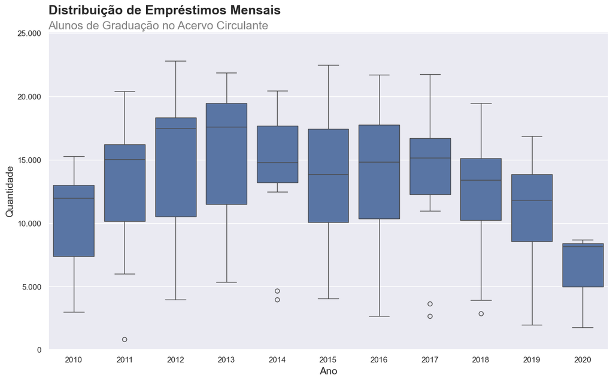

```python
create_boxplot(grad_loan_date,'Ano','Quantidade','Distribuição de Empréstimos Mensais','Alunos de Graduação no Acervo Circulante')
```

#### Analisando os Dados - Boxplot

O gráfico BOXPLOT, é uma ferramenta essencial para análise dos dados, com ele, é possível perceber como nossos dados estão sendo distribuídos, além da fácil visualização de potenciais Outliers.

```python
posgrad_loan = total_loan.query('tipo_vinculo_usuario == "ALUNO DE PÓS-GRADUAÇÃO"')
print(posgrad_loan['colecao'].value_counts())
```

```
colecao
Acervo Circulante                        299201
Dissertações                                934
Obras de Referência                         700
Multimeios                                  559
Teses                                       367
Monografias                                 278
Publicações de Autores do RN                204
Publicações da UFRN                         121
Folhetos                                     60
Necessidades Educacionais Específicas        30
Eventos                                      26
Coleção Mossoroense                          23
Trabalho Acadêmico                           23
Coleção Zila Mamede                          11
Literatura de Cordel                          4
Name: count, dtype: int64
```

#### Agora com os Alunos de Pós-Graduação:

```python
posgrad_loan_col = posgrad_loan.query('colecao == "Acervo Circulante"')
posgrad_loan_col = pd.DataFrame(posgrad_loan_col)
posgrad_loan_col['data_emprestimo'] = pd.to_datetime(posgrad_loan_col['data_emprestimo'])
posgrad_loan_col['Ano'] = posgrad_loan_col['data_emprestimo'].dt.year
posgrad_loan_col['Mes'] = posgrad_loan_col['data_emprestimo'].dt.month
posgrad_loan_date = posgrad_loan_col.loc[:,['Ano','Mes']]
posgrad_loan_date = posgrad_loan_date.value_counts().to_frame('Quantidade').reset_index()
display(posgrad_loan_date)
```

|  | Ano | Mes | Quantidade |
| --- | --- | --- | --- |
| 0 | 2015 | 3 | 3927 |
| 1 | 2017 | 8 | 3837 |
| 2 | 2017 | 3 | 3722 |
| 3 | 2016 | 3 | 3711 |
| 4 | 2016 | 8 | 3662 |
| ... | ... | ... | ... |
| 119 | 2020 | 1 | 1143 |
| 120 | 2010 | 1 | 1105 |
| 121 | 2019 | 12 | 1069 |
| 122 | 2011 | 1 | 465 |
| 123 | 2020 | 6 | 2 |

124 rows × 3 columns

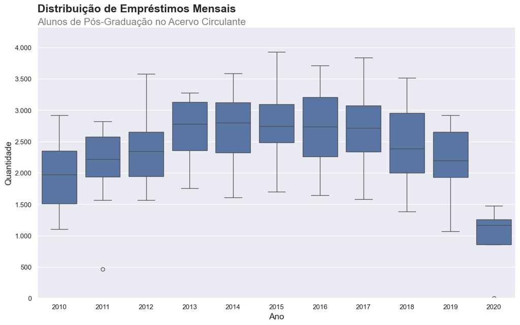

```python
create_boxplot(posgrad_loan_date,'Ano','Quantidade','Distribuição de Empréstimos Mensais','Alunos de Pós-Graduação no Acervo Circulante')
```

#### Analisando os Dados - Boxplot

Após analisar os dois gráficos, é evidente que durante os anos de 2010-2013 houve um grande crescimento, o que abre para perguntas como:

- O que houve durante esses anos para que houvesse crescimento?
- Quais procedimentos podem ser adotados hoje em dia, com base nesse período?

Mas, em contrapartida, a partir de 2018 houve um grande declínio, dessa forma cabe uma investigação para entender o quê está ocorrendo.

### Agora, temos os cursos de cada matriculado. Entã, vamos analisar a quantidade e frequência de empréstimos para esses cursos no decorrer dos anos.

Primeiramente, vamos analisar os graduandos, que compõem a maior parte dos usuários das bibliotecas.

```python
### Parte dos registros em Excel
reg_u2010 = pd.read_excel('matricula_alunos.xlsx', sheet_name= 'Até 2010',skiprows=1)
reg_a2010 = pd.read_excel('matricula_alunos.xlsx', sheet_name= 'Após 2010',skiprows=1)
```

```python
reg_u2010.columns = ['matricula_ou_siape','tipo_vinculo_usuario','curso']
reg_a2010.columns = ['matricula_ou_siape','tipo_vinculo_usuario','curso']
reg_excel = pd.concat([reg_u2010,reg_a2010],ignore_index= True)
reg_excel['matricula_ou_siape'] = reg_excel['matricula_ou_siape'].astype('string')
```

```python
# Parte dos registros em JSON
reg_json = pd.read_json('cadastro_alunos.json')
grad_json = pd.read_json(reg_json['registros'][0])
grad_json['matricula_ou_siape'] = grad_json['matricula_ou_siape'].astype('float')
grad_json['matricula_ou_siape'] = grad_json['matricula_ou_siape'].astype('string')
```

```python
users_grad = pd.concat([reg_excel,grad_json],ignore_index= True)
display(users_grad.head())
```

|  | matricula_ou_siape | tipo_vinculo_usuario | curso |
| --- | --- | --- | --- |
| 0 | 190001688.0 | ALUNO DE GRADUAÇÃO | MATEMÁTICA |
| 1 | 199014489.0 | ALUNO DE GRADUAÇÃO | CIÊNCIAS BIOLÓGICAS |
| 2 | 199735674.0 | ALUNO DE GRADUAÇÃO | MATEMÁTICA |
| 3 | 199812431.0 | ALUNO DE GRADUAÇÃO | LETRAS |
| 4 | 199823670.0 | ALUNO DE GRADUAÇÃO | ECOLOGIA |

```python
total_loan['data_emprestimo'] = pd.to_datetime(total_loan['data_emprestimo'])
reg_loan_date = total_loan.query('tipo_vinculo_usuario == "ALUNO DE GRADUAÇÃO"')
reg_loan_date = reg_loan_date.loc[:,['matricula_ou_siape','data_emprestimo']]
reg_loan_date = reg_loan_date.query('data_emprestimo > 2015')
reg_loan_date = reg_loan_date.reset_index(drop=True)
display(reg_loan_date.head())
```

|  | matricula_ou_siape | data_emprestimo |
| --- | --- | --- |
| 0 | 2013021576.0 | 2015-01-02 09:16:49.566 |
| 1 | 2014026648.0 | 2015-01-02 09:44:42.808 |
| 2 | 2014026648.0 | 2015-01-02 09:44:43.127 |
| 3 | 2010049586.0 | 2015-01-02 10:11:09.837 |
| 4 | 2014021454.0 | 2015-01-02 10:19:38.087 |

```python
print(reg_loan_date.isna().sum())
```

```
matricula_ou_siape    0
data_emprestimo       0
dtype: int64
```

Os cursos selecionadas para a análise dos graduandos foram: Biblioteconomia , Ciências sociais , Comunicação social , Direito , Filosofia e Pedagogia.

```python
### CURSOS SELECIONADOS
reg_select = users_grad.query("curso == ['BIBLIOTECONOMIA', 'CIÊNCIAS SOCIAIS', 'COMUNICAÇÃO SOCIAL', 'DIREITO', 'FILOSOFIA', 'PEDAGOGIA']")
reg_select = reg_loan_date.merge(reg_select)
reg_select['data_emprestimo'] = reg_select['data_emprestimo'].dt.year
display(reg_select.head())
```

|  | matricula_ou_siape | data_emprestimo | tipo_vinculo_usuario | curso |
| --- | --- | --- | --- | --- |
| 0 | 2014021454.0 | 2015 | ALUNO DE GRADUAÇÃO | FILOSOFIA |
| 1 | 2013018187.0 | 2015 | ALUNO DE GRADUAÇÃO | DIREITO |
| 2 | 2014029499.0 | 2015 | ALUNO DE GRADUAÇÃO | CIÊNCIAS SOCIAIS |
| 3 | 2014029499.0 | 2015 | ALUNO DE GRADUAÇÃO | CIÊNCIAS SOCIAIS |
| 4 | 2014029499.0 | 2015 | ALUNO DE GRADUAÇÃO | CIÊNCIAS SOCIAIS |

```python
loan_select = reg_select.iloc[:,[1,3]].value_counts().reset_index().sort_values('data_emprestimo').reset_index(drop=True)
loan_select.columns = ['Ano','Curso','Quantidade']
display(loan_select.head())
```

|  | Ano | Curso | Quantidade |
| --- | --- | --- | --- |
| 0 | 2015 | FILOSOFIA | 6950 |
| 1 | 2015 | BIBLIOTECONOMIA | 7784 |
| 2 | 2015 | DIREITO | 7665 |
| 3 | 2015 | CIÊNCIAS SOCIAIS | 7489 |
| 4 | 2015 | COMUNICAÇÃO SOCIAL | 7147 |

```python
loan_select_pivot = loan_select.pivot_table(index = 'Curso', columns= 'Ano', values= 'Quantidade', aggfunc= 'sum',margins = True, margins_name= 'TOTAL')
display(loan_select_pivot)
```

| Ano Curso | 2015 | 2016 | 2017 | 2018 | 2019 | 2020 | TOTAL |
| --- | --- | --- | --- | --- | --- | --- | --- |
| BIBLIOTECONOMIA | 7784 | 7044 | 7307 | 6378 | 5889 | 900 | 35302 |
| CIÊNCIAS SOCIAIS | 7489 | 6978 | 6918 | 6181 | 5788 | 825 | 34179 |
| COMUNICAÇÃO SOCIAL | 7147 | 7973 | 8253 | 6953 | 5885 | 796 | 37007 |
| DIREITO | 7665 | 7363 | 7885 | 7027 | 5861 | 905 | 36706 |
| FILOSOFIA | 6950 | 7576 | 7389 | 6296 | 5572 | 832 | 34615 |
| PEDAGOGIA | 7189 | 7153 | 7434 | 6518 | 5869 | 866 | 35029 |
| TOTAL | 44224 | 44087 | 45186 | 39353 | 34864 | 5124 | 212838 |

Como já era de se esperar, por análises anteriores, é perceptível que houve uma grande queda no número de empréstimos de livros para cada curso.

### Diferença percentual de empréstimos realizados nos últimos anos (2017, 2018, 2019 e 2022) para cada curso.

Para alunos de PÓS-GRADUAÇÃO

```python
reg_posgrad = pd.read_json(reg_json['registros'][1])
reg_posgrad['matricula_ou_siape'] = reg_posgrad['matricula_ou_siape'].astype('float')
reg_posgrad['matricula_ou_siape'] = reg_posgrad['matricula_ou_siape'].astype('string')
```

```python
total_loan['data_emprestimo'] = pd.to_datetime(total_loan['data_emprestimo'])
reg_loan_date = total_loan.query('tipo_vinculo_usuario == "ALUNO DE PÓS-GRADUAÇÃO"')
reg_loan_date = reg_loan_date.loc[:,['matricula_ou_siape','data_emprestimo']]
reg_loan_date = reg_loan_date.query('data_emprestimo > 2017')
reg_loan_date = reg_loan_date.reset_index(drop=True)
```

```python
reg_all = reg_loan_date.merge(reg_posgrad)
reg_all['data_emprestimo'] = reg_all['data_emprestimo'].dt.year
loan_all = reg_all.iloc[:,[1,3]].value_counts().reset_index().sort_values('data_emprestimo').reset_index(drop=True)
loan_all.columns = ['Ano','Curso','Quantidade']
loan_all.sort_values(by='Curso')
display(loan_all.isna().sum())
```

```
Ano           0
Curso         0
Quantidade    0
dtype: int64
```

```python
## Previsão de 2022 que foi dada.

prediction2022 = {
    'Curso': ['ADMINISTRACAO','ARQUITETURA E URBANISMO','ARTES CENICAS','BIOINFORMATICA','BIOQUIMICA','CIENCIA E ENGENHARIA DE MATERIAIS','CIENCIA TECNOLOGIA E INOVACAO',
               'CIENCIAS DA SAUDE','CIENCIAS ODONTOLOGICAS','DESIGN','ENGENHARIA CIVIL','ENGENHARIA SOFTWARE','FILOSOFIA','GESTAO DA INFORMACAO E DO CONHECIMENTO'],
    'Quantidade': [1905,1896,1920,2302,2090,2010,1960,1730,2405,1900,1920,1890,1903,1855]
    }

prediction2022 = pd.DataFrame(prediction2022)
prediction2022['Ano'] = 2022
loan_all = pd.concat([loan_all,prediction2022]).reset_index(drop=True)
```

```python
def loan_years(year1, year2):
    loan_y1 = loan_all[loan_all['Ano'] == year1].sort_values(by='Curso').reset_index(drop=True)
    loan_y2 = loan_all[loan_all['Ano'] == year2].sort_values(by='Curso').reset_index(drop=True)
    course_table = (((loan_y2['Quantidade'] - loan_y1['Quantidade']) / loan_y1['Quantidade']) * 100).round(2)
    course_table = pd.DataFrame({'Curso': loan_y1['Curso'], str(year2): course_table})
    course_table[str(year2)] = course_table[str(year2)].astype(str) + '%'
    return course_table
```

```python
## Ano de 2022 sendo analisado levando em conta o ano de 2019, já que os anos de 2020,2021 foram de pandemia.
percentage2018 = loan_years(2017,2018)
percentage2019 = loan_years(2018,2019)
percentage2022 = loan_years(2019,2022)
```

```python
merged_df = pd.merge(percentage2018, percentage2019,on='Curso')
merged_df = pd.merge(merged_df,percentage2022,on = 'Curso')
pivoted_df = merged_df.melt(id_vars='Curso', var_name='Ano', value_name='Porcentagem')
pivoted_df = pivoted_df.pivot_table(index = 'Curso', columns= 'Ano', values= 'Porcentagem', aggfunc= 'first')
display(pivoted_df)
```

| Ano Curso | 2018 | 2019 | 2022 |
| --- | --- | --- | --- |
| ADMINISTRAÇÃO | -8.75% | -26.94% | 12.59% |
| ARQUITETURA E URBANISMO | -13.22% | -5.16% | 4.29% |
| ARTES CÊNICAS | -1.56% | -12.97% | 5.96% |
| BIOINFORMÁTICA | -12.6% | -4.65% | 26.14% |
| BIOQUÍMICA | -15.26% | 5.81% | 1.6% |
| CIÊNCIA E ENGENHARIA DE MATERIAIS | -8.89% | -4.83% | 0.1% |
| CIÊNCIA, TECNOLOGIA E INOVAÇÃO | -2.07% | -14.33% | -3.26% |
| CIÊNCIAS DA SAÚDE | -18.41% | -8.11% | -5.21% |
| CIÊNCIAS ODONTOLÓGICAS | 5.22% | -15.98% | 12.7% |
| DESIGN | -19.1% | 0.16% | 3.2% |
| ENGENHARIA CIVIL | -12.92% | -4.79% | -3.47% |
| ENGENHARIA DE SOFTWARE | -10.29% | -15.08% | 0.16% |
| FILOSOFIA | -5.62% | -13.43% | 7.33% |
| GESTÃO DA INFORMAÇÃO E DO CONHECIMENTO | -16.55% | -6.35% | 4.74% |

Até mesmo entre os alunos de pós-graduação houve uma queda brusca em relação ao ano anterior, ao que tudo indica a procura por livros fisícos foi diminuindo ao longo dos anos. Provavalmente, é decorrente as novas tecnologias, acervo desatualizado, e poucas ações de marketing efetivas para captar leitores, além disso é importante analisar o contexto geral dos anos de 2017 a 2019 por essa queda, se normalizando apenas em 2022.

### E este foi o fim deste projeto deste meu projeto de Análise de Dados das Bibliotecas da UFRN, o desafio e os datasets foram disponiblizados pela Alura, e o professor Francisco Foz durante o desafio (#7DaysofCode). Espero que tenha gostado!

### Autor

Kaua Maia